# Chapter 2 - Exercises

My attempt of the exericse questions from Chapter 2: Statistical Learning

Kaustav Sen  
2021-10-05

# Conceptual

## Question 7

Creating a function to calculate the “Euclidean distance” between two points.

```r
distance_euclidean <- function(x1, x2) {
  # assume that both x1 and x2 are vectors of the same length
  square_diff <- (x1 - x2) ^ 2
  sqrt(sum(square_diff))
}
```

Storing the data provided in the question as a `data.frame`

```r
data <- data.frame(x1 = c(0, 2, 0, 0, -1, 1),
                   x2 = c(3, 0, 1, 1, 0, 1),
                   x3 = c(0, 0, 3, 2, 1, 1),
                   y = c("Red", "Red", "Red", "Green", "Green", "Red"))
data
```

```
  x1 x2 x3     y
1  0  3  0   Red
2  2  0  0   Red
3  0  1  3   Red
4  0  1  2 Green
5 -1  0  1 Green
6  1  1  1   Red
```

1. Computing the Euclidean distance from the test point

```r
test_point <- c(0, 0, 0)
distances <- apply(data[, -4], 1, function(x) distance_euclidean(test_point, x))

distances
```

```
[1] 3.000000 2.000000 3.162278 2.236068 1.414214 1.732051
```

# Applied

## Question 8

1. Loading in the `college.csv` data set and storing it in a variable called `college`.

```r
college <- read.csv("https://www.statlearning.com/s/College.csv")

head(college)
```

```
                             X Private Apps Accept Enroll Top10perc
1 Abilene Christian University     Yes 1660   1232    721        23
2           Adelphi University     Yes 2186   1924    512        16
3               Adrian College     Yes 1428   1097    336        22
4          Agnes Scott College     Yes  417    349    137        60
5    Alaska Pacific University     Yes  193    146     55        16
6            Albertson College     Yes  587    479    158        38
  Top25perc F.Undergrad P.Undergrad Outstate Room.Board Books
1        52        2885         537     7440       3300   450
2        29        2683        1227    12280       6450   750
3        50        1036          99    11250       3750   400
4        89         510          63    12960       5450   450
5        44         249         869     7560       4120   800
6        62         678          41    13500       3335   500
  Personal PhD Terminal S.F.Ratio perc.alumni Expend Grad.Rate
1     2200  70       78      18.1          12   7041        60
2     1500  29       30      12.2          16  10527        56
3     1165  53       66      12.9          30   8735        54
4      875  92       97       7.7          37  19016        59
5     1500  76       72      11.9           2  10922        15
6      675  67       73       9.4          11   9727        55
```

2. Setting the row-names for the college data set and also using the `fix()` function

```r
rownames(college) <- college[,1]
# fix(college)
```

Eliminating the first column from the data.

```r
college <- college[, -1]
head(college)
```

```
                             Private Apps Accept Enroll Top10perc
Abilene Christian University     Yes 1660   1232    721        23
Adelphi University               Yes 2186   1924    512        16
Adrian College                   Yes 1428   1097    336        22
Agnes Scott College              Yes  417    349    137        60
Alaska Pacific University        Yes  193    146     55        16
Albertson College                Yes  587    479    158        38
                             Top25perc F.Undergrad P.Undergrad
Abilene Christian University        52        2885         537
Adelphi University                  29        2683        1227
Adrian College                      50        1036          99
Agnes Scott College                 89         510          63
Alaska Pacific University           44         249         869
Albertson College                   62         678          41
                             Outstate Room.Board Books Personal PhD
Abilene Christian University     7440       3300   450     2200  70
Adelphi University              12280       6450   750     1500  29
Adrian College                  11250       3750   400     1165  53
Agnes Scott College             12960       5450   450      875  92
Alaska Pacific University        7560       4120   800     1500  76
Albertson College               13500       3335   500      675  67
                             Terminal S.F.Ratio perc.alumni Expend
Abilene Christian University       78      18.1          12   7041
Adelphi University                 30      12.2          16  10527
Adrian College                     66      12.9          30   8735
Agnes Scott College                97       7.7          37  19016
Alaska Pacific University          72      11.9           2  10922
Albertson College                  73       9.4          11   9727
                             Grad.Rate
Abilene Christian University        60
Adelphi University                  56
Adrian College                      54
Agnes Scott College                 59
Alaska Pacific University           15
Albertson College                   55
```

3. 1. Using the `summary()` function in order to get a numerical summary of the variables in the data.

```r
summary(college)
```

```
   Private               Apps           Accept          Enroll
 Length:777         Min.   :   81   Min.   :   72   Min.   :  35
 Class :character   1st Qu.:  776   1st Qu.:  604   1st Qu.: 242
 Mode  :character   Median : 1558   Median : 1110   Median : 434
                    Mean   : 3002   Mean   : 2019   Mean   : 780
                    3rd Qu.: 3624   3rd Qu.: 2424   3rd Qu.: 902
                    Max.   :48094   Max.   :26330   Max.   :6392
   Top10perc       Top25perc      F.Undergrad     P.Undergrad
 Min.   : 1.00   Min.   :  9.0   Min.   :  139   Min.   :    1.0
 1st Qu.:15.00   1st Qu.: 41.0   1st Qu.:  992   1st Qu.:   95.0
 Median :23.00   Median : 54.0   Median : 1707   Median :  353.0
 Mean   :27.56   Mean   : 55.8   Mean   : 3700   Mean   :  855.3
 3rd Qu.:35.00   3rd Qu.: 69.0   3rd Qu.: 4005   3rd Qu.:  967.0
 Max.   :96.00   Max.   :100.0   Max.   :31643   Max.   :21836.0
    Outstate       Room.Board       Books           Personal
 Min.   : 2340   Min.   :1780   Min.   :  96.0   Min.   : 250
 1st Qu.: 7320   1st Qu.:3597   1st Qu.: 470.0   1st Qu.: 850
 Median : 9990   Median :4200   Median : 500.0   Median :1200
 Mean   :10441   Mean   :4358   Mean   : 549.4   Mean   :1341
 3rd Qu.:12925   3rd Qu.:5050   3rd Qu.: 600.0   3rd Qu.:1700
 Max.   :21700   Max.   :8124   Max.   :2340.0   Max.   :6800
      PhD            Terminal       S.F.Ratio      perc.alumni
 Min.   :  8.00   Min.   : 24.0   Min.   : 2.50   Min.   : 0.00
 1st Qu.: 62.00   1st Qu.: 71.0   1st Qu.:11.50   1st Qu.:13.00
 Median : 75.00   Median : 82.0   Median :13.60   Median :21.00
 Mean   : 72.66   Mean   : 79.7   Mean   :14.09   Mean   :22.74
 3rd Qu.: 85.00   3rd Qu.: 92.0   3rd Qu.:16.50   3rd Qu.:31.00
 Max.   :103.00   Max.   :100.0   Max.   :39.80   Max.   :64.00
     Expend        Grad.Rate
 Min.   : 3186   Min.   : 10.00
 1st Qu.: 6751   1st Qu.: 53.00
 Median : 8377   Median : 65.00
 Mean   : 9660   Mean   : 65.46
 3rd Qu.:10830   3rd Qu.: 78.00
 Max.   :56233   Max.   :118.00
```

2. Using the `pairs()` function to plot a scatter plot for the first 10 columns in the data.

The first column is non-numeric, so ignored it from the subset.

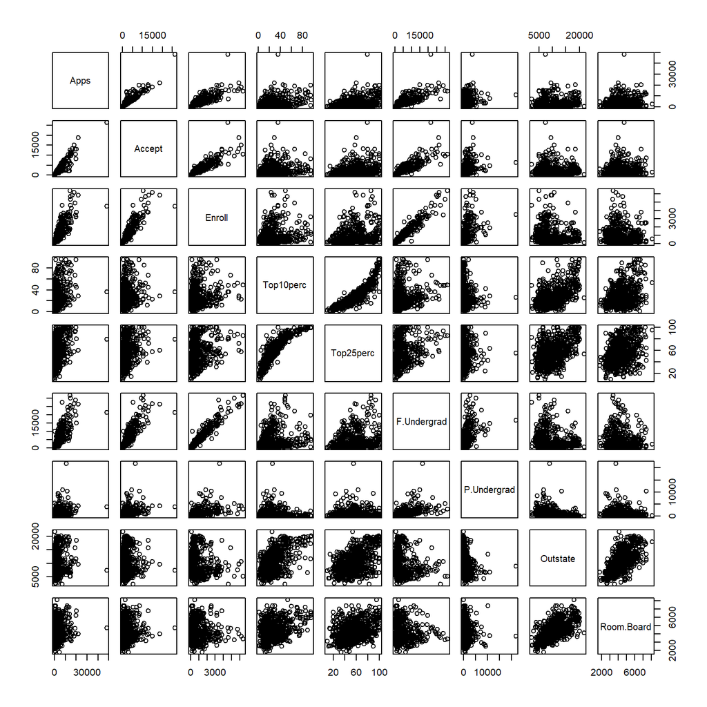

```r
college_cols_10 <- college[, 2:10]

pairs(college_cols_10)
```

3. Creating a box-plot

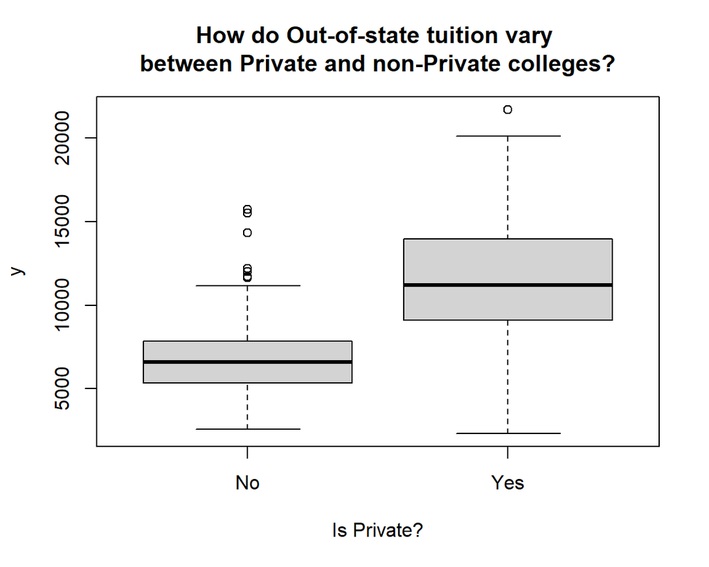

```r
plot(as.factor(college$Private), college$Outstate,
     xlab = "Is Private?",
     main = "How do Out-of-state tuition vary \nbetween Private and non-Private colleges?")
```

4. Creating a new qualitative variable, `Elite`

```r
Elite <- rep("No", nrow(college))
Elite[college$Top10perc > 50] <- "Yes"
Elite <- as.factor(Elite)
college <- data.frame(college, Elite)
```

```r
summary(college$Elite)
```

```
 No Yes
699  78
```

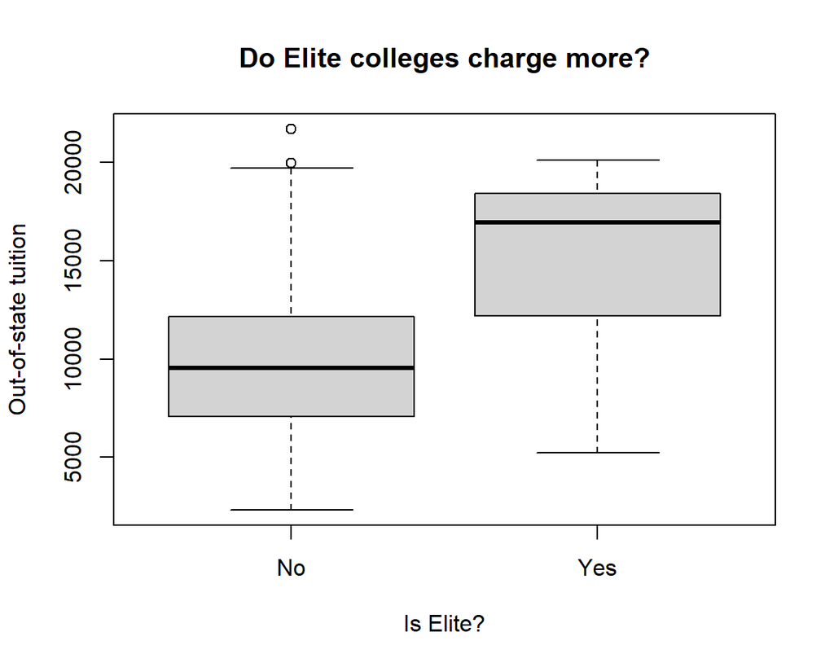

```r
plot(college$Elite, college$Outstate,
     xlab = "Is Elite?",
     ylab = "Out-of-state tuition",
     main = "Do Elite colleges charge more?")
```

22. Creating some histograms

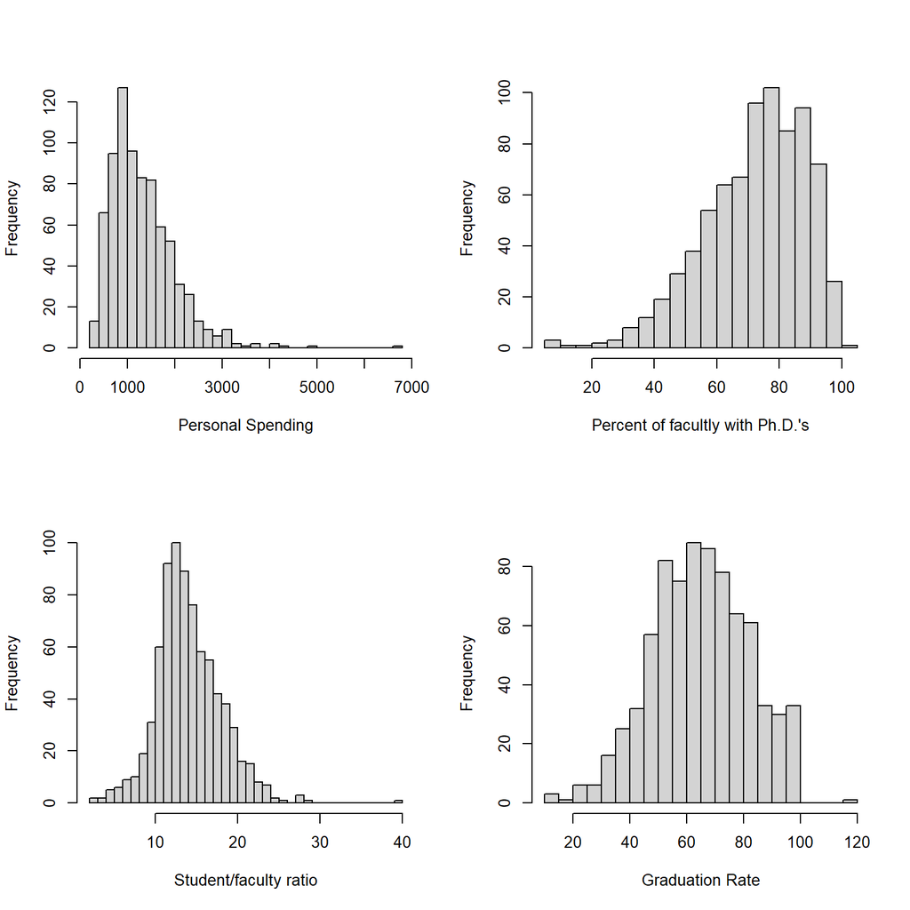

```r
par(mfrow = c(2, 2))
hist(college$Personal, breaks = 30, xlab = "Personal Spending", main = "")
hist(college$PhD, breaks = 30, xlab = "Percent of facultly with Ph.D.'s", main = "")
hist(college$S.F.Ratio, breaks = 30, xlab = "Student/faculty ratio", main = "")
hist(college$Grad.Rate, breaks = 30, xlab = "Graduation Rate", main = "")
```

6. Some further explorations of the data set…

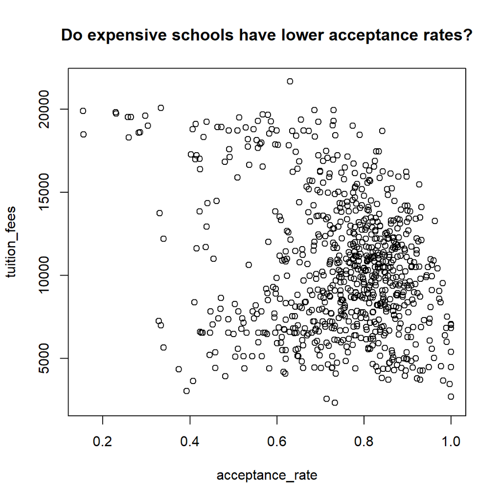

```r
# Using a scatter-plot to see if more expensive schools have a lower acceptance rate
acceptance_rate <- college$Accept / college$Apps
tuition_fees <- college$Outstate
par(mfrow = c(1,1))
plot(acceptance_rate, tuition_fees, main = "Do expensive schools have lower acceptance rates?")
```

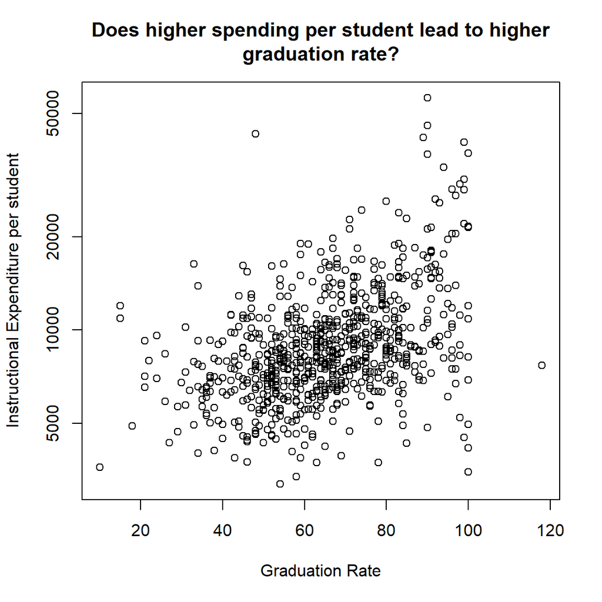

```r
plot(college$Grad.Rate, college$Expend, log = "y",
     xlab = "Graduation Rate", ylab = "Instructional Expenditure per student",
     main = "Does higher spending per student lead to higher\ngraduation rate?")
```

## Question 9

Reading in the `Auto` data and removing the `NA` values.

```r
Auto <- read.table("https://www.statlearning.com/s/Auto.data",
                   header = TRUE, na.strings = "?")
Auto <- na.omit(Auto)
```

1. Taking a look at the structure of the data set

```r
str(Auto)
```

```
'data.frame':   392 obs. of  9 variables:
 $ mpg         : num  18 15 18 16 17 15 14 14 14 15 ...
 $ cylinders   : int  8 8 8 8 8 8 8 8 8 8 ...
 $ displacement: num  307 350 318 304 302 429 454 440 455 390 ...
 $ horsepower  : num  130 165 150 150 140 198 220 215 225 190 ...
 $ weight      : num  3504 3693 3436 3433 3449 ...
 $ acceleration: num  12 11.5 11 12 10.5 10 9 8.5 10 8.5 ...
 $ year        : int  70 70 70 70 70 70 70 70 70 70 ...
 $ origin      : int  1 1 1 1 1 1 1 1 1 1 ...
 $ name        : chr  "chevrolet chevelle malibu" "buick skylark 320" "plymouth satellite" "amc rebel sst" ...
 - attr(*, "na.action")= 'omit' Named int [1:5] 33 127 331 337 355
  ..- attr(*, "names")= chr [1:5] "33" "127" "331" "337" ...
```

The variables `name`, `cylinders` and `origin` are qualitative. Rest all of the other variables are quantitative in nature.

2. Calculating the range of each quantitative variable.

```r
# Store the quantitative and qualitative variable names separately
qual_cols <- c("origin", "name", "cylinders")
quant_cols <- setdiff(names(Auto), qual_cols)

sapply(Auto[, quant_cols], range)
```

```
      mpg displacement horsepower weight acceleration year
[1,]  9.0           68         46   1613          8.0   70
[2,] 46.6          455        230   5140         24.8   82
```

3. Calculating the mean and standard deviation of each quantitative variable.

```r
output_summary_stats <- function(x) {
  list(mean = mean(x), standard_deviation = sd(x))
}
```

```r
sapply(Auto[, quant_cols], output_summary_stats)
```

```
                   mpg      displacement horsepower weight
mean               23.44592 194.412      104.4694   2977.584
standard_deviation 7.805007 104.644      38.49116   849.4026
                   acceleration year
mean               15.54133     75.97959
standard_deviation 2.758864     3.683737
```

4. Sub-setting the data and then re-calculate the summary statistics.

```r
Auto_subset <- Auto[-c(10:85), quant_cols]
sapply(Auto_subset[, quant_cols], output_summary_stats)
```

```
                   mpg      displacement horsepower weight
mean               24.40443 187.2405     100.7215   2935.972
standard_deviation 7.867283 99.67837     35.70885   811.3002
                   acceleration year
mean               15.7269      77.14557
standard_deviation 2.693721     3.106217
```

5. Exploring predictors using scatter-plots

```r
library(ggplot2)

plot_scatter_mpg <- function(var) {
 ggplot(Auto) +
  geom_point(aes({{ var }}, mpg, color = as.factor(cylinders)),
             size = 2, alpha = 0.7) +
  guides(color = guide_legend("Number of cylinders", "top", title.hjust = 0.5)) +
  theme_custom(base_family = "Inter")
}
```

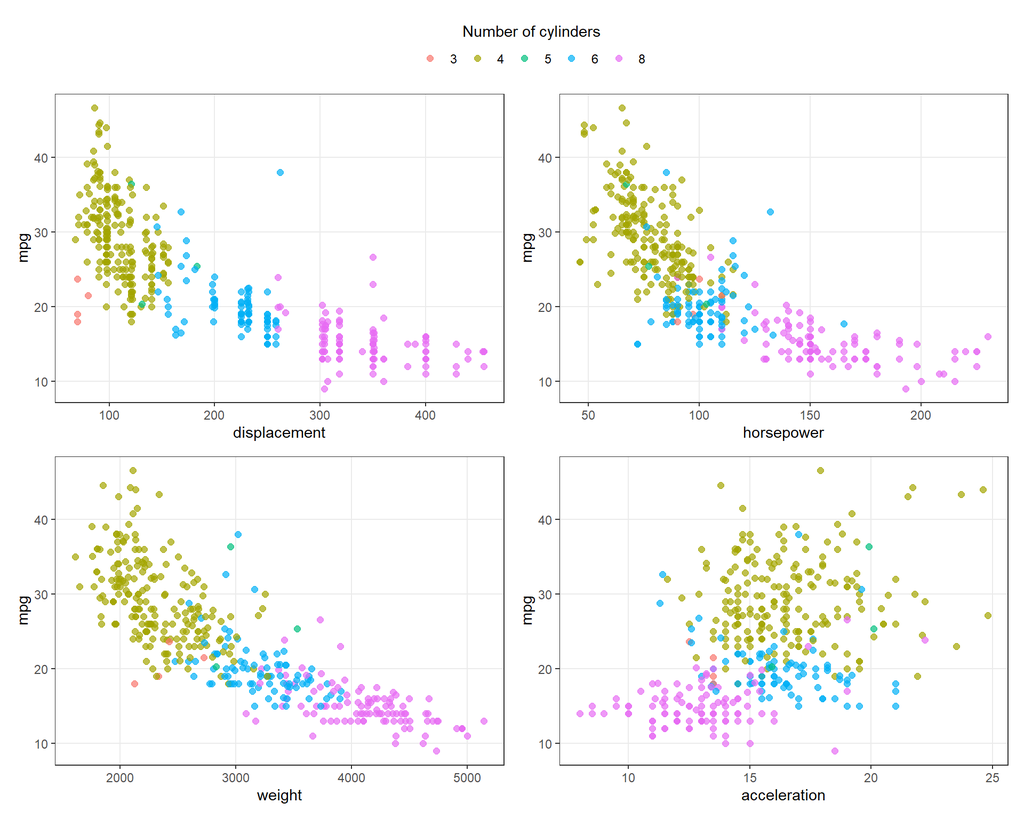

```r
library(patchwork)

plot_scatter_mpg(displacement) +
  plot_scatter_mpg(horsepower) +
  plot_scatter_mpg(weight) +
  plot_scatter_mpg(acceleration) +
  plot_layout(ncol = 2, guides = "collect") &
  theme(legend.position = "top")
```

6. There seems to be a negative correlation between `mpg` and the following variables:
- `displacment`
- `horsepower` and
- `weight`

Plus, the number of cylinders also affects `mpg`. Further, there exists a slight positive correlation between `mpg` and `acceleration`. So, these variables can be used as a starting point for the modeling process.

## Question 10

1. Reading in the `Boston` data set

```r
library(ISLR2)

head(Boston)
```

```
     crim zn indus chas   nox    rm  age    dis rad tax ptratio lstat
1 0.00632 18  2.31    0 0.538 6.575 65.2 4.0900   1 296    15.3  4.98
2 0.02731  0  7.07    0 0.469 6.421 78.9 4.9671   2 242    17.8  9.14
3 0.02729  0  7.07    0 0.469 7.185 61.1 4.9671   2 242    17.8  4.03
4 0.03237  0  2.18    0 0.458 6.998 45.8 6.0622   3 222    18.7  2.94
5 0.06905  0  2.18    0 0.458 7.147 54.2 6.0622   3 222    18.7  5.33
6 0.02985  0  2.18    0 0.458 6.430 58.7 6.0622   3 222    18.7  5.21
  medv
1 24.0
2 21.6
3 34.7
4 33.4
5 36.2
6 28.7
```

```r
nrow(Boston) # number of rows in the data set
```

```
[1] 506
```

```r
ncol(Boston) # number of columns in the data set
```

```
[1] 13
```

Each row represents a house in the suburb in Boston. The columns represent in the features of each house.

2. Pairwise scatter plots

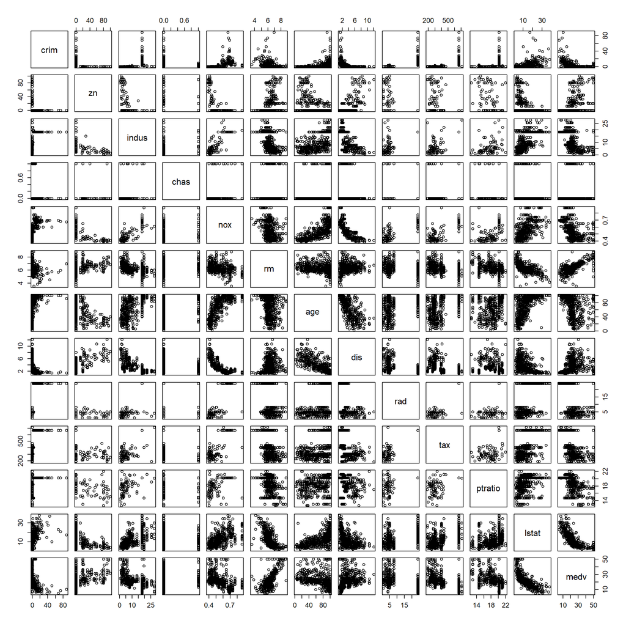

```r
pairs(Boston, family = "Inter", cex.axis = 1.2, cex.labels = 1.5)
```

There is some relationship between `medv` and `lstat`, `rm`.

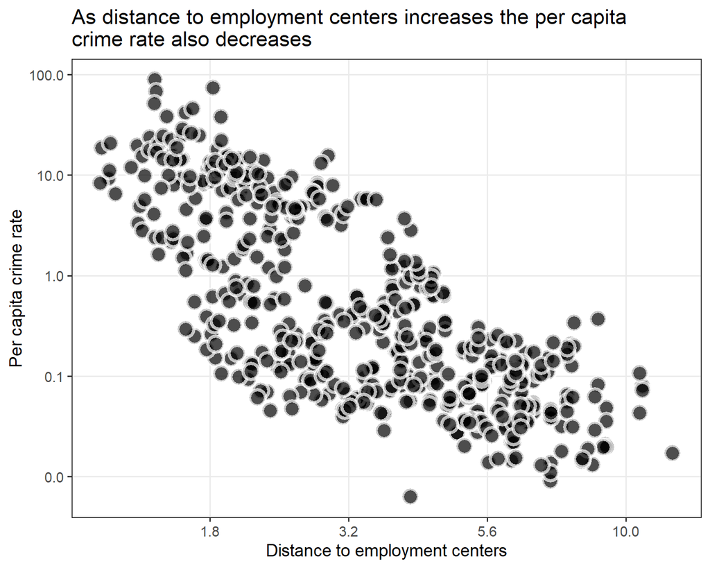

```r
ggplot(Boston) +
  geom_point(aes(dis, crim), shape = 21, stroke = 2,
             size = 5, fill = "black", color = "white", alpha = 0.7) +
  scale_x_log10("Distance to employment centers", breaks = 10^seq(0, 1, 0.25),
                labels = scales::number_format(accuracy = 0.1)) +
  scale_y_log10("Per capita crime rate",
                labels = scales::number_format(accuracy = 0.1)) +
  labs(
    title = "As distance to employment centers increases the per capita\ncrime rate also decreases"
  ) +
  theme_custom(base_size = 14)
```

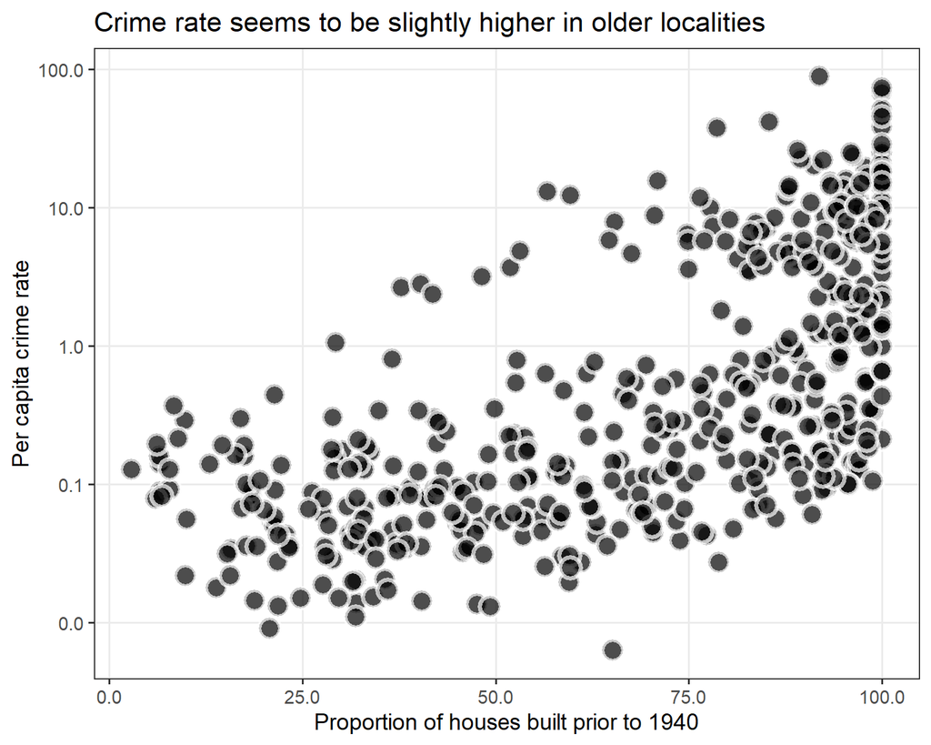

```r
ggplot(Boston) +
  geom_point(aes(age, crim), shape = 21, stroke = 2,
             size = 5, fill = "black", color = "white", alpha = 0.7) +
  scale_x_continuous("Proportion of houses built prior to 1940",
                labels = scales::number_format(accuracy = 0.1)) +
  scale_y_log10("Per capita crime rate",
                labels = scales::number_format(accuracy = 0.1)) +
  labs(
    title = "Crime rate seems to be slightly higher in older localities"
  ) +
  theme_custom(base_size = 14)
```

4. Exploring tracts with high crime rates.

```r
Boston$tax_bracket <- cut(Boston$tax, breaks = c(0, 500, 1000), labels = c("Low", "High"))

table(Boston$tax_bracket)
```

```
 Low High
 369  137
```

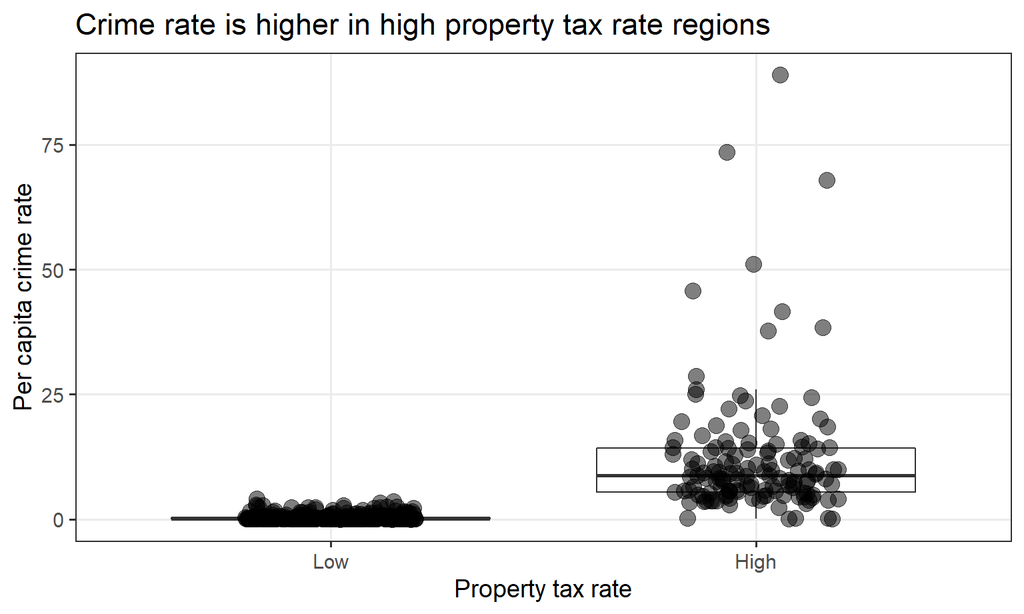

```r
ggplot(Boston, aes(tax_bracket, crim)) +
  geom_boxplot(outlier.size = 0, outlier.stroke = 0) +
  geom_jitter(width = 0.2, height = 0, size = 4, alpha = 0.5) +
  labs(
    title = "Crime rate is higher in high property tax rate regions",
    x = "Property tax rate",
    y = "Per capita crime rate"
  ) +
  theme_custom(base_size = 14)
```

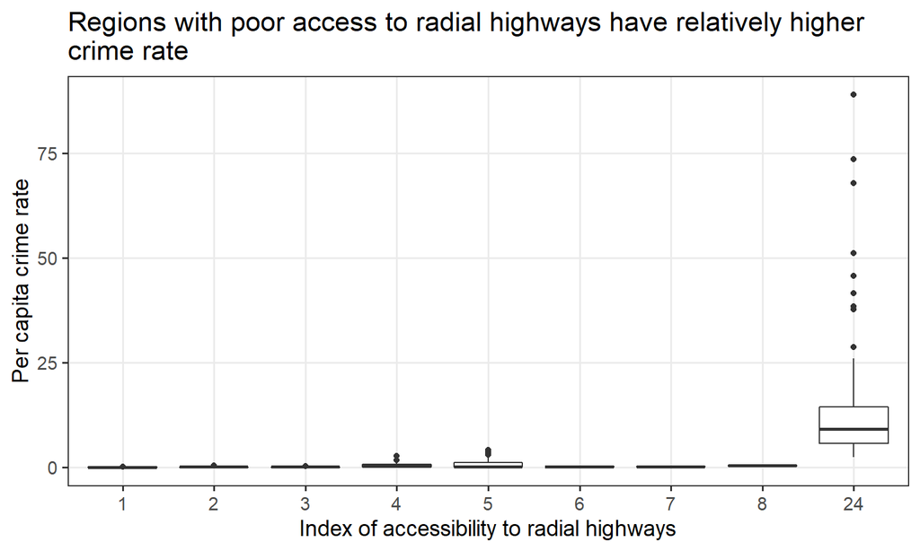

```r
ggplot(Boston, aes(as.factor(rad), crim)) +
  geom_boxplot() +
  labs(
    title = "Regions with poor access to radial highways have relatively higher\ncrime rate",
    x = "Index of accessibility to radial highways",
    y = "Per capita crime rate"
  ) +
  theme_custom(base_size = 14)
```

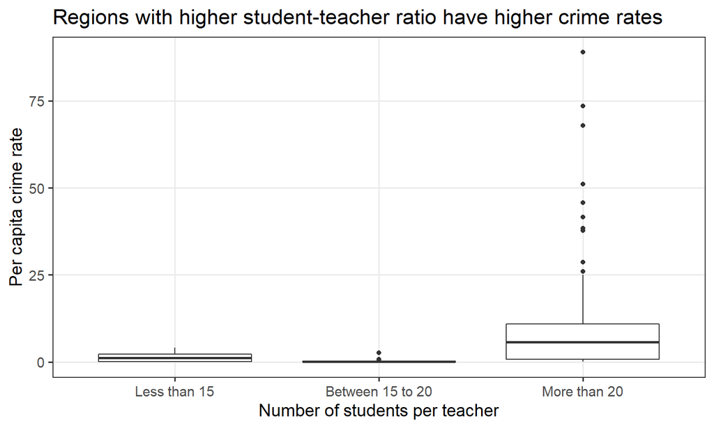

```r
Boston$ptratio_cut <- cut(Boston$ptratio, breaks = c(0, 15, 20, Inf),
                          labels = c("Less than 15", "Between 15 to 20", "More than 20"))

ggplot(Boston, aes(ptratio_cut, crim)) +
  geom_boxplot() +
  labs(
    title = "Regions with higher student-teacher ratio have higher crime rates",
    x = "Number of students per teacher",
    y = "Per capita crime rate"
  ) +
  theme_custom(base_size = 14)
```

5. There are `35` census tracts which bound to the Charles river.

```r
table(Boston$chas)
```

```
  0   1
471  35
```

6. The median pupil-teacher ratio is `19.05`.

```r
median(Boston$ptratio)
```

```
[1] 19.05
```